Finance Dataset. This is a dataset about the Banking Sector of East Africa.This was data collected from a questionaire to East African residents about access of a bank account.

# a.Import the libraries

```python
#Reading data and data manipulation
import pandas as pd
#mathematical operations and working with arrays
import numpy as np
#Import Matplotlib a library used for visualisations
import matplotlib.pyplot as plt
#import seaborn , a visualisation library.
import seaborn as sns
```

# b.import the data

```python
#We will use read_csv to import the data
url = 'http://bit.ly/FinancialDataset'
finance = pd.read_csv(url)
finance
```

|  | country | year | uniqueid | Has a Bank account | Type of Location | Cell Phone Access | household_size | Respondent Age | gender_of_respondent | The relathip with head | marital_status | Level of Educuation | Type of Job |
| --- | --- | --- | --- | --- | --- | --- | --- | --- | --- | --- | --- | --- | --- |
| 0 | Kenya | 2018 | uniqueid_1 | Yes | Rural | Yes | 3.0 | 24.0 | Female | Spouse | Married/Living together | Secondary education | Self employed |
| 1 | Kenya | 2018 | uniqueid_2 | No | Rural | No | 5.0 | 70.0 | Female | Head of Household | Widowed | No formal education | Government Dependent |
| 2 | Kenya | 2018 | uniqueid_3 | Yes | Urban | Yes | 5.0 | 26.0 | Male | Other relative | Single/Never Married | Vocational/Specialised training | Self employed |
| 3 | Kenya | 2018 | uniqueid_4 | No | Rural | Yes | 5.0 | 34.0 | Female | Head of Household | Married/Living together | Primary education | Formally employed Private |
| 4 | Kenya | 2018 | uniqueid_5 | No | Urban | No | 8.0 | 26.0 | Male | Child | Single/Never Married | Primary education | Informally employed |
| ... | ... | ... | ... | ... | ... | ... | ... | ... | ... | ... | ... | ... | ... |
| 23519 | Uganda | 2018 | uniqueid_2113 | No | Rural | Yes | 4.0 | 48.0 | Female | Head of Household | Divorced/Seperated | No formal education | Other Income |
| 23520 | Uganda | 2018 | uniqueid_2114 | No | Rural | Yes | 2.0 | 27.0 | Female | Head of Household | Single/Never Married | Secondary education | Other Income |
| 23521 | Uganda | 2018 | uniqueid_2115 | No | Rural | Yes | 5.0 | 27.0 | Female | Parent | Widowed | Primary education | Other Income |
| 23522 | Uganda | 2018 | uniqueid_2116 | No | Urban | Yes | 7.0 | 30.0 | Female | Parent | Divorced/Seperated | Secondary education | Self employed |
| 23523 | Uganda | 2018 | uniqueid_2117 | No | Rural | Yes | 10.0 | 20.0 | Male | Child | Single/Never Married | Secondary education | No Income |

23524 rows × 13 columns

```python
#Check the shape of the Data (rows and columns)
print("The number of columns is " + str(finance.shape[1]))
print("The number of rows is "  + str(finance.shape[0]))
```

```
The number of columns is 13
The number of rows is 23524
```

```python
#Check the first 5 rows
finance.head()
```

|  | country | year | uniqueid | Has a Bank account | Type of Location | Cell Phone Access | household_size | Respondent Age | gender_of_respondent | The relathip with head | marital_status | Level of Educuation | Type of Job |
| --- | --- | --- | --- | --- | --- | --- | --- | --- | --- | --- | --- | --- | --- |
| 0 | Kenya | 2018 | uniqueid_1 | Yes | Rural | Yes | 3.0 | 24.0 | Female | Spouse | Married/Living together | Secondary education | Self employed |
| 1 | Kenya | 2018 | uniqueid_2 | No | Rural | No | 5.0 | 70.0 | Female | Head of Household | Widowed | No formal education | Government Dependent |
| 2 | Kenya | 2018 | uniqueid_3 | Yes | Urban | Yes | 5.0 | 26.0 | Male | Other relative | Single/Never Married | Vocational/Specialised training | Self employed |
| 3 | Kenya | 2018 | uniqueid_4 | No | Rural | Yes | 5.0 | 34.0 | Female | Head of Household | Married/Living together | Primary education | Formally employed Private |
| 4 | Kenya | 2018 | uniqueid_5 | No | Urban | No | 8.0 | 26.0 | Male | Child | Single/Never Married | Primary education | Informally employed |

```python
#Checking the last 5 items of the dataset
finance.tail()
```

|  | country | year | uniqueid | Has a Bank account | Type of Location | Cell Phone Access | household_size | Respondent Age | gender_of_respondent | The relathip with head | marital_status | Level of Educuation | Type of Job |
| --- | --- | --- | --- | --- | --- | --- | --- | --- | --- | --- | --- | --- | --- |
| 23519 | Uganda | 2018 | uniqueid_2113 | No | Rural | Yes | 4.0 | 48.0 | Female | Head of Household | Divorced/Seperated | No formal education | Other Income |
| 23520 | Uganda | 2018 | uniqueid_2114 | No | Rural | Yes | 2.0 | 27.0 | Female | Head of Household | Single/Never Married | Secondary education | Other Income |
| 23521 | Uganda | 2018 | uniqueid_2115 | No | Rural | Yes | 5.0 | 27.0 | Female | Parent | Widowed | Primary education | Other Income |
| 23522 | Uganda | 2018 | uniqueid_2116 | No | Urban | Yes | 7.0 | 30.0 | Female | Parent | Divorced/Seperated | Secondary education | Self employed |
| 23523 | Uganda | 2018 | uniqueid_2117 | No | Rural | Yes | 10.0 | 20.0 | Male | Child | Single/Never Married | Secondary education | No Income |

# c. Checking the data

```python
# Determining the no. of records in our dataset
#
finance.count()
```

```
country                   23510
year                      23524
uniqueid                  23524
Has a Bank account        23488
Type of Location          23509
Cell Phone Access         23513
household_size            23496
Respondent Age            23490
gender_of_respondent      23490
The relathip with head    23520
marital_status            23492
Level of Educuation       23495
Type of Job               23494
dtype: int64
```

```python
#Getting a round up information about the data.
finance.info()
```

```
<class 'pandas.core.frame.DataFrame'>
RangeIndex: 23524 entries, 0 to 23523
Data columns (total 13 columns):
 #   Column                  Non-Null Count  Dtype
---  ------                  --------------  -----
 0   country                 23510 non-null  object
 1   year                    23524 non-null  int64
 2   uniqueid                23524 non-null  object
 3   Has a Bank account      23488 non-null  object
 4   Type of Location        23509 non-null  object
 5   Cell Phone Access       23513 non-null  object
 6   household_size          23496 non-null  float64
 7   Respondent Age          23490 non-null  float64
 8   gender_of_respondent    23490 non-null  object
 9   The relathip with head  23520 non-null  object
 10  marital_status          23492 non-null  object
 11  Level of Educuation     23495 non-null  object
 12  Type of Job             23494 non-null  object
dtypes: float64(2), int64(1), object(10)
memory usage: 2.3+ MB
```

```python
#Getting summary statistics of the finance dataframe.
finance.describe()
```

|  | year | household_size | Respondent Age |
| --- | --- | --- | --- |
| count | 23524.000000 | 23496.000000 | 23490.000000 |
| mean | 2016.979000 | 3.681818 | 38.804300 |
| std | 0.899669 | 2.279933 | 16.519996 |
| min | 2016.000000 | 0.000000 | 16.000000 |
| 25% | 2016.000000 | 2.000000 | 26.000000 |
| 50% | 2017.000000 | 3.000000 | 35.000000 |
| 75% | 2018.000000 | 5.000000 | 49.000000 |
| max | 2056.000000 | 21.000000 | 100.000000 |

```python
#Check for Range of the Data.
finance.index
```

```
RangeIndex(start=0, stop=23524, step=1)
```

```python
#Checking for the data array.
finance.values
```

```
array([['Kenya', 2018, 'uniqueid_1', ..., 'Married/Living together',
        'Secondary education', 'Self employed'],
       ['Kenya', 2018, 'uniqueid_2', ..., 'Widowed',
        'No formal education', 'Government Dependent'],
       ['Kenya', 2018, 'uniqueid_3', ..., 'Single/Never Married',
        'Vocational/Specialised training', 'Self employed'],
       ...,
       ['Uganda', 2018, 'uniqueid_2115', ..., 'Widowed',
        'Primary education', 'Other Income'],
       ['Uganda', 2018, 'uniqueid_2116', ..., 'Divorced/Seperated',
        'Secondary education', 'Self employed'],
       ['Uganda', 2018, 'uniqueid_2117', ..., 'Single/Never Married',
        'Secondary education', 'No Income']], dtype=object)
```

```python
#The columns
finance.columns
```

```
Index(['country', 'year', 'uniqueid', 'Has a Bank account', 'Type of Location',
       'Cell Phone Access', 'household_size', 'Respondent Age',
       'gender_of_respondent', 'The relathip with head', 'marital_status',
       'Level of Educuation', 'Type of Job'],
      dtype='object')
```

```python
#How many unique items are in each item column
finance.nunique()
```

```
country                      4
year                         6
uniqueid                  8735
Has a Bank account           2
Type of Location             2
Cell Phone Access            2
household_size              21
Respondent Age              85
gender_of_respondent         2
The relathip with head       6
marital_status               5
Level of Educuation          7
Type of Job                 10
dtype: int64
```

```python
# Getting the unique values in the Type of Job column
finance['Type of Job'].unique()
```

```
array(['Self employed', 'Government Dependent',
       'Formally employed Private', 'Informally employed',
       'Formally employed Government', 'Farming and Fishing',
       'Remittance Dependent', 'Other Income',
       'Dont Know/Refuse to answer', nan, 'No Income'], dtype=object)
```

```python
# Getting the unique values in the gender_of_respondent column
finance['gender_of_respondent'].unique()
```

```
array(['Female', 'Male', nan], dtype=object)
```

```python
# Getting the unique values in the Relationship with head column
finance['The relathip with head'].unique()
```

```
array(['Spouse', 'Head of Household', 'Other relative', 'Child', 'Parent',
       'Other non-relatives', nan], dtype=object)
```

```python
# Getting the unique values in the Cell Phone Access column
finance['Cell Phone Access'].unique()
```

```
array(['Yes', 'No', nan], dtype=object)
```

```python
# Getting the unique values in the Marital Status column
finance['marital_status'].unique()
```

```
array(['Married/Living together', 'Widowed', 'Single/Never Married',
       'Divorced/Seperated', 'Dont know', nan], dtype=object)
```

```python
# Getting the unique values in the Country column
finance['country'].unique()
```

```
array(['Kenya', 'Rwanda', 'Tanzania', nan, 'Uganda'], dtype=object)
```

Having seen the nan values in the different columns, we will need to clean the data.

# d.Cleaning

This involves checking and dropping/replacing null values ,renaming column names,

```python
#Renaming the columns.
#We will rename the columns into better names separating with underscore and utilizing capital letters.
finance.rename(columns ={'country':'Country','uniqueid':'unique_Id','year':'Year','Has a Bank account':'Has_a_Bank_Account','Type of Location':'Type_of_Location',
       'Cell Phone Access':'Cell_Phone_Access', 'household_size':'Household_Size', 'Respondent Age':'Respondent_Age',
       'gender_of_respondent':'Gender_of_Respondent', 'The relathip with head':'The_Relationship_with_Head', 'marital_status':'Marital_Status',
       'Level of Educuation':'Level_of_Education', 'Type of Job':'Type_Of_Job'}, inplace =True)
```

```python
finance.head(1)
```

|  | Country | Year | unique_Id | Has_a_Bank_Account | Type_of_Location | Cell_Phone_Access | Household_Size | Respondent_Age | Gender_of_Respondent | The_Relationship_with_Head | Marital_Status | Level_of_Education | Type_Of_Job |
| --- | --- | --- | --- | --- | --- | --- | --- | --- | --- | --- | --- | --- | --- |
| 0 | Kenya | 2018 | uniqueid_1 | Yes | Rural | Yes | 3.0 | 24.0 | Female | Spouse | Married/Living together | Secondary education | Self employed |

```python
#dropping columns
finance = finance.drop({'unique_Id'},axis=1)
```

```python
finance.head(1)
```

|  | Country | Year | Has_a_Bank_Account | Type_of_Location | Cell_Phone_Access | Household_Size | Respondent_Age | Gender_of_Respondent | The_Relationship_with_Head | Marital_Status | Level_of_Education | Type_Of_Job |
| --- | --- | --- | --- | --- | --- | --- | --- | --- | --- | --- | --- | --- |
| 0 | Kenya | 2018 | Yes | Rural | Yes | 3.0 | 24.0 | Female | Spouse | Married/Living together | Secondary education | Self employed |

```python
#Checking for Null values.
finance.isnull().sum()
```

```
Country                       14
Year                           0
Has_a_Bank_Account            36
Type_of_Location              15
Cell_Phone_Access             11
Household_Size                28
Respondent_Age                34
Gender_of_Respondent          34
The_Relationship_with_Head     4
Marital_Status                32
Level_of_Education            29
Type_Of_Job                   30
dtype: int64
```

```python
#Replace null values
#finance.fillna
```

```python
#Drop null values
finance = finance.dropna(how ='any')
```

```python
finance.isnull().sum()
```

```
Country                       0
Year                          0
Has_a_Bank_Account            0
Type_of_Location              0
Cell_Phone_Access             0
Household_Size                0
Respondent_Age                0
Gender_of_Respondent          0
The_Relationship_with_Head    0
Marital_Status                0
Level_of_Education            0
Type_Of_Job                   0
dtype: int64
```

Check for duplicates

```python
finance.duplicated(keep='last')
```

```
0        False
1        False
2        False
3        False
4        False
         ...
23519    False
23520    False
23521    False
23522    False
23523    False
Length: 23343, dtype: bool
```

```python
#Check shape to see the dropped columns
finance.shape
```

```
(23343, 12)
```

```python
#No duplicates because no items
```

```python
finance.head()
```

|  | Country | Year | Has_a_Bank_Account | Type_of_Location | Cell_Phone_Access | Household_Size | Respondent_Age | Gender_of_Respondent | The_Relationship_with_Head | Marital_Status | Level_of_Education | Type_Of_Job |
| --- | --- | --- | --- | --- | --- | --- | --- | --- | --- | --- | --- | --- |
| 0 | Kenya | 2018 | Yes | Rural | Yes | 3.0 | 24.0 | Female | Spouse | Married/Living together | Secondary education | Self employed |
| 1 | Kenya | 2018 | No | Rural | No | 5.0 | 70.0 | Female | Head of Household | Widowed | No formal education | Government Dependent |
| 2 | Kenya | 2018 | Yes | Urban | Yes | 5.0 | 26.0 | Male | Other relative | Single/Never Married | Vocational/Specialised training | Self employed |
| 3 | Kenya | 2018 | No | Rural | Yes | 5.0 | 34.0 | Female | Head of Household | Married/Living together | Primary education | Formally employed Private |
| 4 | Kenya | 2018 | No | Urban | No | 8.0 | 26.0 | Male | Child | Single/Never Married | Primary education | Informally employed |

# e.Checking for outliers

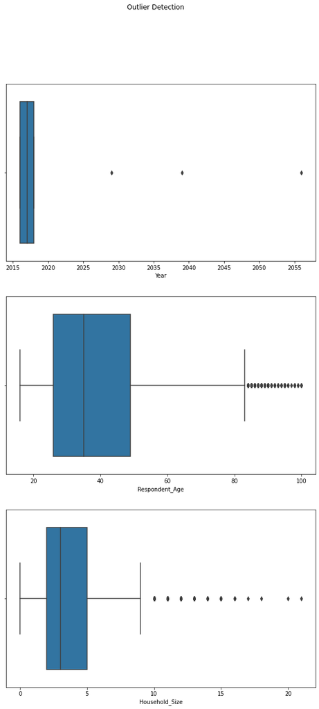

```python
fig, (ax1, ax2,ax3) = plt.subplots(3,1, figsize=(10,20))

fig.suptitle('Outlier Detection')

sns.boxplot(finance['Year'], ax= ax1, orient = 'v')
sns.boxplot(finance['Respondent_Age'],ax = ax2, orient = 'v')
sns.boxplot(finance['Household_Size'], ax = ax3, orient = 'v')
```

```python
#Dropping
Q1 = finance.quantile(0.25)
Q3 = finance.quantile(0.75)
IQR = Q3 - Q1
print(IQR)
```

```
Year               2.0
Household_Size     3.0
Respondent_Age    23.0
dtype: float64
```

```python
new_finance = finance[~((finance < (Q1 - 1.5 * IQR)) |(finance > (Q3 + 1.5 * IQR))).any(axis=1)]
```

```python
new_finance.shape
```

```
(22725, 12)
```

Use Z-score to drop the outliers

```python
from scipy import stats

z = np.abs(stats.zscore(finance))
print(z)
```

[output not shown]

```python
threshold = 3
print(np.where(z > 3))
```

[output not shown]

```python
new_finance2 = finance[(z < 3).all(axis=1)]
```

```python
new_finance2.shape()
```

[output not shown]

# f.Exploratory Data Analysis

In statistics, exploratory data analysis is an approach to analyzing data sets to summarize their main characteristics, often with visual methods.

## i).**Univariate**

- Univariate analysis is a form of statistical analysis. The key fact is that only one variable is involved.

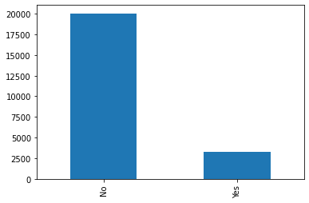

```python
finance['Has_a_Bank_Account'].value_counts().plot(kind ='bar')
```

The above shows most of the E.A people did not have a bank.

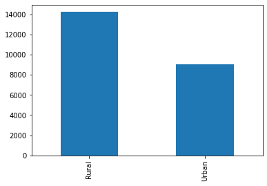

```python
finance['Type_of_Location'].value_counts().plot(kind= 'bar')
```

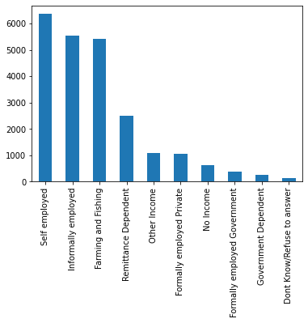

```python
finance['Type_Of_Job'].value_counts().plot(kind= 'bar')
```

Most of the people who answered the survey , were mostly self employed and informally employed or practising farming and fishing.

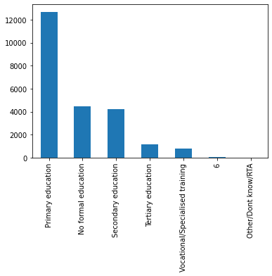

```python
finance['Level_of_Education'].value_counts().plot(kind= 'bar')
```

Most of the people in the data have mostly reached to the primary education.

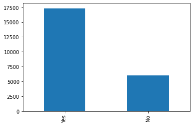

```python
finance['Cell_Phone_Access'].value_counts().plot(kind= 'bar')
```

Most of the those who took the banking survey had a Cell Phone Access.

```python
#In our data as shown above we have 4 countries. We can obtain each country as one and try to to obtain the
#univariate analysis.We will start with Kenya
kenya_finance = finance[finance['Country']=='Kenya']
kenya_finance.head()

#We have created a new dataframe with only the Kenyan data. Noe wecan use this to obtain some bar charts.
```

|  | Country | Year | Has_a_Bank_Account | Type_of_Location | Cell_Phone_Access | Household_Size | Respondent_Age | Gender_of_Respondent | The_Relationship_with_Head | Marital_Status | Level_of_Education | Type_Of_Job |
| --- | --- | --- | --- | --- | --- | --- | --- | --- | --- | --- | --- | --- |
| 0 | Kenya | 2018 | Yes | Rural | Yes | 3.0 | 24.0 | Female | Spouse | Married/Living together | Secondary education | Self employed |
| 1 | Kenya | 2018 | No | Rural | No | 5.0 | 70.0 | Female | Head of Household | Widowed | No formal education | Government Dependent |
| 2 | Kenya | 2018 | Yes | Urban | Yes | 5.0 | 26.0 | Male | Other relative | Single/Never Married | Vocational/Specialised training | Self employed |
| 3 | Kenya | 2018 | No | Rural | Yes | 5.0 | 34.0 | Female | Head of Household | Married/Living together | Primary education | Formally employed Private |
| 4 | Kenya | 2018 | No | Urban | No | 8.0 | 26.0 | Male | Child | Single/Never Married | Primary education | Informally employed |

```python
kenya_finance.shape
```

```
(6064, 12)
```

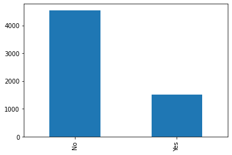

```python
kenya_finance['Has_a_Bank_Account'].value_counts().plot(kind= 'bar')
```

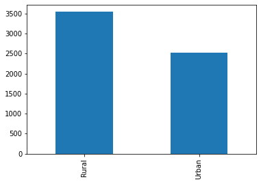

```python
kenya_finance['Type_of_Location'].value_counts().plot(kind= 'bar')
```

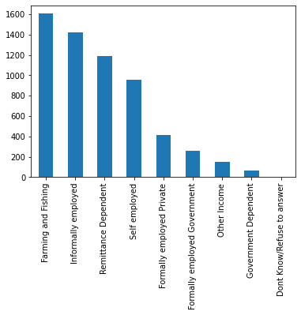

```python
kenya_finance['Type_Of_Job'].value_counts().plot(kind= 'bar')
```

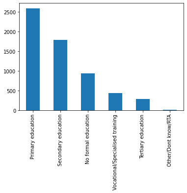

```python
kenya_finance['Level_of_Education'].value_counts().plot(kind= 'bar')
```

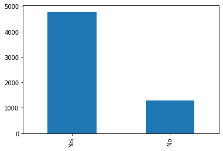

```python
kenya_finance['Cell_Phone_Access'].value_counts().plot(kind= 'bar')
```

## **ii).Bivariate analysis**

- Bivariate analysis refers to the analysis of two variables to determine relationships between them

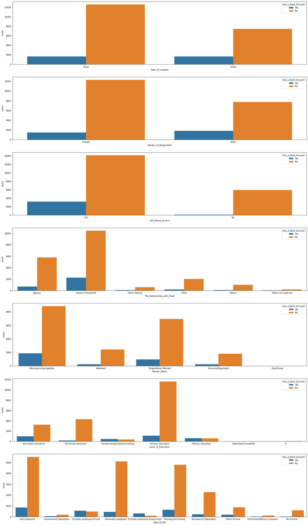

```python
# At this stage, we are going to create counplots for each column togetheer with the 'Has a bank account' column.
# Our purpose for doing this, is investigate how each column relates with our target column.

# Define how the axes of our plots
f, axes = plt.subplots(7, 1, figsize=[25, 45])

sns.countplot('Type_of_Location',hue='Has_a_Bank_Account', data=finance, ax=axes[0])
sns.countplot('Gender_of_Respondent',hue='Has_a_Bank_Account', data=finance, ax=axes[1])
sns.countplot('Cell_Phone_Access',hue='Has_a_Bank_Account', data=finance, ax=axes[2])
sns.countplot('The_Relationship_with_Head', hue= 'Has_a_Bank_Account', data=finance, ax=axes[3])
sns.countplot('Marital_Status', hue= 'Has_a_Bank_Account', data=finance, ax=axes[4])
sns.countplot('Level_of_Education', hue= 'Has_a_Bank_Account', data=finance, ax=axes[5])
sns.countplot('Type_Of_Job', hue= 'Has_a_Bank_Account', data=finance, ax=axes[6])
```

# g.Correlation

correlation is any statistical association, though it commonly refers to the degree to which a pair of variables are linearly related.

```python
# First we are going to covert our categorical data  to numerical data so that we can be able to create a correlation matrix.
# Convert catergorical data to Numerical
from sklearn.preprocessing import LabelEncoder
en = LabelEncoder()
finance['Level_of_Education'] = en.fit_transform(finance['Level_of_Education'])
finance['Type_Of_Job'] = en.fit_transform(finance['Type_Of_Job'])
finance['The_Relationship_with_Head'] = en.fit_transform(finance['The_Relationship_with_Head'])
finance['Cell_Phone_Access'] = en.fit_transform(finance['Cell_Phone_Access'])
finance['Gender_of_Respondent'] = en.fit_transform(finance['Gender_of_Respondent'])
finance['Marital_Status'] = en.fit_transform(finance['Marital_Status'])
finance['Has_a_Bank_Account'] = en.fit_transform(finance['Has_a_Bank_Account'])
finance['Type_of_Location'] = en.fit_transform(finance['Type_of_Location'])
```

```python
#Correlation

#-1(negative) to 1(positive correlation)
```

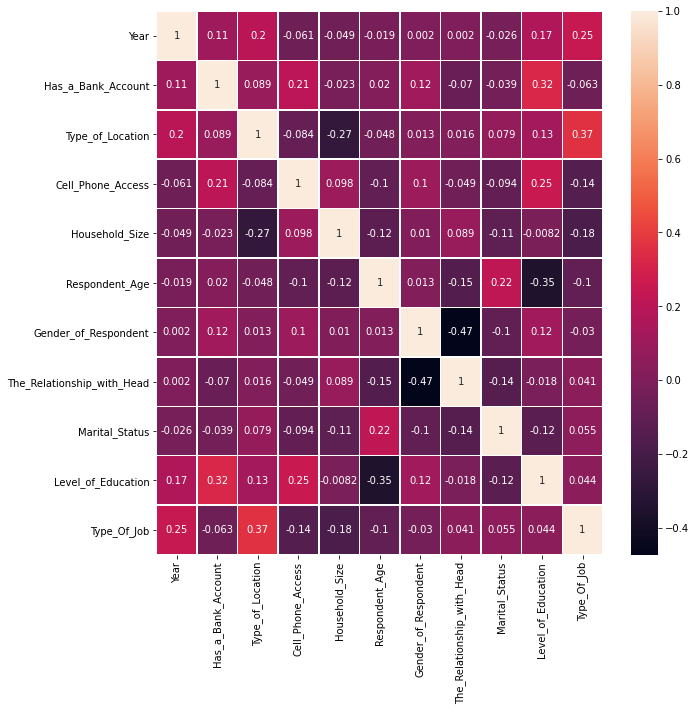

```python
# Create a correlation matrix
corrMatrix = finance.corr()
corrMatrix

# Vizualise the correlation matrix using a heat map

fig, ax = plt.subplots(figsize=(10,10))
sns.heatmap(corrMatrix, annot=True,  linewidths=.5, ax=ax)
```

```python
!pip install nbconvert
```

```python
!jupyter nbconvert --to html Exploratory_Data_Analysis.ipynb
```

[output not shown]

[output cut: 75 more lines]

[output not shown]